# Worksheet_6 (1)

## Worksheet 6

## Exercise 1

Repeat the analysis of the IMDb data using a similarly structured neural network. There we used a dictionary of size 10,000. Consider the effects of varying the dictionary size. Try the values 1000, 3000, 5000, and 10,000, and compare the results using a plot and discuss.

```python
import matplotlib.pyplot as plt
from tensorflow.keras.datasets import imdb
from tensorflow.keras.preprocessing import sequence
from tensorflow.keras.models import Sequential
from tensorflow.keras.layers import Embedding, GlobalAveragePooling1D, Dense, SimpleRNN
import pandas as pd
import numpy as np
from sklearn.preprocessing import StandardScaler
from sklearn.model_selection import train_test_split
from sklearn.metrics import r2_score
```

```python
# Function to run a sentiment classification model for a given vocabulary size
def imdb_data(vocab_size, batch_size=512, epochs=10, maxlen=500):
    (x_train, y_train), (x_test, y_test) = imdb.load_data(num_words=vocab_size)
    x_train = sequence.pad_sequences(x_train, maxlen=maxlen)
    x_test = sequence.pad_sequences(x_test, maxlen=maxlen)

    model = Sequential([
        Embedding(vocab_size, 32, input_length=maxlen),
        GlobalAveragePooling1D(),
        Dense(1, activation='sigmoid')
    ])
    model.compile(optimizer='adam', loss='binary_crossentropy', metrics=['accuracy'])

    history = model.fit(
        x_train, y_train,
        epochs=epochs,
        batch_size=batch_size,
        validation_split=0.2,
        verbose=1
    )

    test_loss, test_accuracy = model.evaluate(x_test, y_test, verbose=0)
    return history, test_loss, test_accuracy
```

```python
# Vocabulary sizes to test
vocab_sizes = [1000, 3000, 5000, 10000]
results = {}

# Run model for each vocab size
for vocab in vocab_sizes:
    print(f"\nTraining with vocab size = {vocab}")
    hist, loss, acc = imdb_data(vocab)
    results[vocab] = {
        "val_loss": hist.history["val_loss"],
        "test_loss": loss,
        "test_accuracy": acc
    }
```

```
Training with vocab size = 1000
```

```
40/40 ━━━━━━━━━━━━━━━━━━━━ 4s 75ms/step - accuracy: 0.5177 - loss: 0.6918 - val_accuracy: 0.5648 - val_loss: 0.6859
40/40 ━━━━━━━━━━━━━━━━━━━━ 4s 57ms/step - accuracy: 0.5770 - loss: 0.6823 - val_accuracy: 0.6046 - val_loss: 0.6750
40/40 ━━━━━━━━━━━━━━━━━━━━ 2s 57ms/step - accuracy: 0.6320 - loss: 0.6728 - val_accuracy: 0.6728 - val_loss: 0.6614
40/40 ━━━━━━━━━━━━━━━━━━━━ 3s 68ms/step - accuracy: 0.6723 - loss: 0.6590 - val_accuracy: 0.6474 - val_loss: 0.6481
40/40 ━━━━━━━━━━━━━━━━━━━━ 6s 90ms/step - accuracy: 0.6476 - loss: 0.6448 - val_accuracy: 0.7252 - val_loss: 0.6263
40/40 ━━━━━━━━━━━━━━━━━━━━ 3s 76ms/step - accuracy: 0.6972 - loss: 0.6270 - val_accuracy: 0.7294 - val_loss: 0.6094
40/40 ━━━━━━━━━━━━━━━━━━━━ 4s 85ms/step - accuracy: 0.7304 - loss: 0.6064 - val_accuracy: 0.7450 - val_loss: 0.5903
40/40 ━━━━━━━━━━━━━━━━━━━━ 5s 83ms/step - accuracy: 0.7219 - loss: 0.5914 - val_accuracy: 0.7512 - val_loss: 0.5735
40/40 ━━━━━━━━━━━━━━━━━━━━ 3s 78ms/step - accuracy: 0.7611 - loss: 0.5723 - val_accuracy: 0.7702 - val_loss: 0.5559
40/40 ━━━━━━━━━━━━━━━━━━━━ 5s 64ms/step - accuracy: 0.7788 - loss: 0.5500 - val_accuracy: 0.7688 - val_loss: 0.5407

Training with vocab size = 3000
40/40 ━━━━━━━━━━━━━━━━━━━━ 4s 70ms/step - accuracy: 0.5295 - loss: 0.6907 - val_accuracy: 0.5894 - val_loss: 0.6837
40/40 ━━━━━━━━━━━━━━━━━━━━ 6s 104ms/step - accuracy: 0.5845 - loss: 0.6812 - val_accuracy: 0.6088 - val_loss: 0.6706
40/40 ━━━━━━━━━━━━━━━━━━━━ 3s 58ms/step - accuracy: 0.6234 - loss: 0.6673 - val_accuracy: 0.7016 - val_loss: 0.6531
40/40 ━━━━━━━━━━━━━━━━━━━━ 2s 61ms/step - accuracy: 0.6644 - loss: 0.6509 - val_accuracy: 0.7156 - val_loss: 0.6342
40/40 ━━━━━━━━━━━━━━━━━━━━ 3s 64ms/step - accuracy: 0.7216 - loss: 0.6319 - val_accuracy: 0.7296 - val_loss: 0.6149
40/40 ━━━━━━━━━━━━━━━━━━━━ 3s 78ms/step - accuracy: 0.7357 - loss: 0.6100 - val_accuracy: 0.7432 - val_loss: 0.5946
40/40 ━━━━━━━━━━━━━━━━━━━━ 3s 72ms/step - accuracy: 0.7629 - loss: 0.5906 - val_accuracy: 0.7428 - val_loss: 0.5758
40/40 ━━━━━━━━━━━━━━━━━━━━ 3s 66ms/step - accuracy: 0.7295 - loss: 0.5733 - val_accuracy: 0.7254 - val_loss: 0.5619
40/40 ━━━━━━━━━━━━━━━━━━━━ 3s 64ms/step - accuracy: 0.7786 - loss: 0.5505 - val_accuracy: 0.7956 - val_loss: 0.5346
40/40 ━━━━━━━━━━━━━━━━━━━━ 3s 70ms/step - accuracy: 0.8063 - loss: 0.5317 - val_accuracy: 0.8000 - val_loss: 0.5180

Training with vocab size = 5000
40/40 ━━━━━━━━━━━━━━━━━━━━ 4s 68ms/step - accuracy: 0.5246 - loss: 0.6917 - val_accuracy: 0.5922 - val_loss: 0.6849
40/40 ━━━━━━━━━━━━━━━━━━━━ 2s 51ms/step - accuracy: 0.5662 - loss: 0.6832 - val_accuracy: 0.6514 - val_loss: 0.6736
40/40 ━━━━━━━━━━━━━━━━━━━━ 2s 52ms/step - accuracy: 0.6430 - loss: 0.6700 - val_accuracy: 0.6046 - val_loss: 0.6594
40/40 ━━━━━━━━━━━━━━━━━━━━ 2s 50ms/step - accuracy: 0.6593 - loss: 0.6556 - val_accuracy: 0.6910 - val_loss: 0.6392
40/40 ━━━━━━━━━━━━━━━━━━━━ 3s 71ms/step - accuracy: 0.6952 - loss: 0.6359 - val_accuracy: 0.6452 - val_loss: 0.6246
40/40 ━━━━━━━━━━━━━━━━━━━━ 2s 62ms/step - accuracy: 0.6644 - loss: 0.6241 - val_accuracy: 0.7418 - val_loss: 0.5985
40/40 ━━━━━━━━━━━━━━━━━━━━ 2s 51ms/step - accuracy: 0.7579 - loss: 0.5931 - val_accuracy: 0.7454 - val_loss: 0.5788
40/40 ━━━━━━━━━━━━━━━━━━━━ 2s 51ms/step - accuracy: 0.7606 - loss: 0.5732 - val_accuracy: 0.7662 - val_loss: 0.5575
40/40 ━━━━━━━━━━━━━━━━━━━━ 3s 51ms/step - accuracy: 0.7875 - loss: 0.5501 - val_accuracy: 0.7662 - val_loss: 0.5397
40/40 ━━━━━━━━━━━━━━━━━━━━ 3s 61ms/step - accuracy: 0.7728 - loss: 0.5307 - val_accuracy: 0.8056 - val_loss: 0.5172

Training with vocab size = 10000
40/40 ━━━━━━━━━━━━━━━━━━━━ 4s 74ms/step - accuracy: 0.5137 - loss: 0.6927 - val_accuracy: 0.5084 - val_loss: 0.6860
40/40 ━━━━━━━━━━━━━━━━━━━━ 5s 63ms/step - accuracy: 0.5525 - loss: 0.6839 - val_accuracy: 0.6632 - val_loss: 0.6752
40/40 ━━━━━━━━━━━━━━━━━━━━ 3s 71ms/step - accuracy: 0.6126 - loss: 0.6729 - val_accuracy: 0.6860 - val_loss: 0.6606
40/40 ━━━━━━━━━━━━━━━━━━━━ 3s 66ms/step - accuracy: 0.6921 - loss: 0.6557 - val_accuracy: 0.6014 - val_loss: 0.6487
40/40 ━━━━━━━━━━━━━━━━━━━━ 4s 89ms/step - accuracy: 0.6607 - loss: 0.6401 - val_accuracy: 0.7334 - val_loss: 0.6208
40/40 ━━━━━━━━━━━━━━━━━━━━ 4s 66ms/step - accuracy: 0.7213 - loss: 0.6175 - val_accuracy: 0.7580 - val_loss: 0.5983
40/40 ━━━━━━━━━━━━━━━━━━━━ 3s 68ms/step - accuracy: 0.7614 - loss: 0.5938 - val_accuracy: 0.7502 - val_loss: 0.5786
40/40 ━━━━━━━━━━━━━━━━━━━━ 6s 94ms/step - accuracy: 0.7717 - loss: 0.5726 - val_accuracy: 0.7362 - val_loss: 0.5610
40/40 ━━━━━━━━━━━━━━━━━━━━ 4s 62ms/step - accuracy: 0.7743 - loss: 0.5526 - val_accuracy: 0.7760 - val_loss: 0.5374
40/40 ━━━━━━━━━━━━━━━━━━━━ 3s 63ms/step - accuracy: 0.8032 - loss: 0.5270 - val_accuracy: 0.8054 - val_loss: 0.5161
```

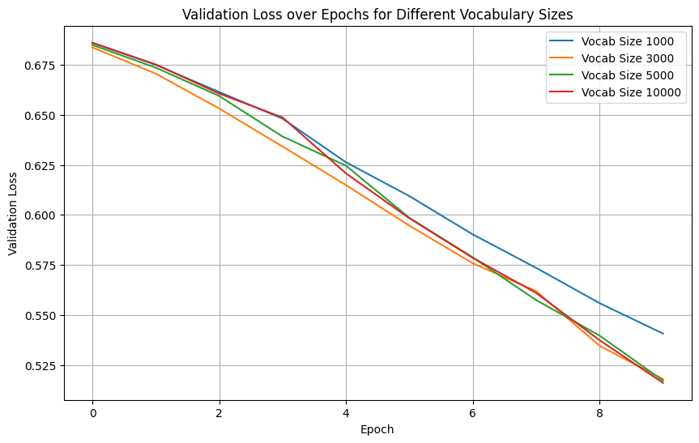

```python
# Plot validation loss across vocab sizes
plt.figure(figsize=(10, 6))
for vocab in vocab_sizes:
    plt.plot(results[vocab]["val_loss"], label=f"Vocab Size {vocab}")
plt.title("Validation Loss over Epochs for Different Vocabulary Sizes")
plt.xlabel("Epoch")
plt.ylabel("Validation Loss")
plt.legend()
plt.grid(True)
plt.show()
```

All models tend to improve with time, demonstrated by a decrease in validation loss as training epochs progress.

In contrast, vocabulary sizes of 3,000, 5,000, and 10000 have been shown to deliver strong performance outcomes. However, it's important to note that larger vocabularies can increase computational costs and raise the risk of overfitting, particularly when working with smaller datasets.

Now using the size of dictionary you find to be sufficient, test out two new batch sizes, show a plot of the convergence of the model, and comment on the results.

```python
batch_sizes = [64, 1024]
batch_results = {}

for b in batch_sizes:
    print(f"Training with batch size {b}")
    hist, loss, acc = imdb_data(vocab_size=10000, batch_size=b)
    batch_results[b] = hist.history  # store only the history for plotting
```

```
Training with batch size 64
313/313 ━━━━━━━━━━━━━━━━━━━━ 5s 12ms/step - accuracy: 0.5401 - loss: 0.6873 - val_accuracy: 0.6416 - val_loss: 0.6495
313/313 ━━━━━━━━━━━━━━━━━━━━ 5s 15ms/step - accuracy: 0.7034 - loss: 0.6244 - val_accuracy: 0.7640 - val_loss: 0.5449
313/313 ━━━━━━━━━━━━━━━━━━━━ 4s 12ms/step - accuracy: 0.7816 - loss: 0.5257 - val_accuracy: 0.8286 - val_loss: 0.4602
313/313 ━━━━━━━━━━━━━━━━━━━━ 4s 11ms/step - accuracy: 0.8282 - loss: 0.4401 - val_accuracy: 0.8464 - val_loss: 0.4113
313/313 ━━━━━━━━━━━━━━━━━━━━ 6s 15ms/step - accuracy: 0.8522 - loss: 0.3857 - val_accuracy: 0.8210 - val_loss: 0.3982
313/313 ━━━━━━━━━━━━━━━━━━━━ 4s 11ms/step - accuracy: 0.8636 - loss: 0.3547 - val_accuracy: 0.8538 - val_loss: 0.3617
313/313 ━━━━━━━━━━━━━━━━━━━━ 4s 11ms/step - accuracy: 0.8792 - loss: 0.3204 - val_accuracy: 0.8586 - val_loss: 0.3443
313/313 ━━━━━━━━━━━━━━━━━━━━ 5s 15ms/step - accuracy: 0.8854 - loss: 0.3004 - val_accuracy: 0.8580 - val_loss: 0.3379
313/313 ━━━━━━━━━━━━━━━━━━━━ 3s 11ms/step - accuracy: 0.8891 - loss: 0.2893 - val_accuracy: 0.8742 - val_loss: 0.3174
313/313 ━━━━━━━━━━━━━━━━━━━━ 5s 11ms/step - accuracy: 0.9016 - loss: 0.2608 - val_accuracy: 0.8770 - val_loss: 0.3110
Training with batch size 1024
20/20 ━━━━━━━━━━━━━━━━━━━━ 5s 202ms/step - accuracy: 0.5099 - loss: 0.6923 - val_accuracy: 0.5984 - val_loss: 0.6876
20/20 ━━━━━━━━━━━━━━━━━━━━ 5s 176ms/step - accuracy: 0.5576 - loss: 0.6863 - val_accuracy: 0.6026 - val_loss: 0.6807
20/20 ━━━━━━━━━━━━━━━━━━━━ 3s 172ms/step - accuracy: 0.6054 - loss: 0.6787 - val_accuracy: 0.6584 - val_loss: 0.6720
20/20 ━━━━━━━━━━━━━━━━━━━━ 4s 187ms/step - accuracy: 0.6343 - loss: 0.6705 - val_accuracy: 0.7036 - val_loss: 0.6618
20/20 ━━━━━━━━━━━━━━━━━━━━ 5s 170ms/step - accuracy: 0.6771 - loss: 0.6604 - val_accuracy: 0.6594 - val_loss: 0.6513
20/20 ━━━━━━━━━━━━━━━━━━━━ 5s 171ms/step - accuracy: 0.7076 - loss: 0.6477 - val_accuracy: 0.7234 - val_loss: 0.6378
20/20 ━━━━━━━━━━━━━━━━━━━━ 6s 213ms/step - accuracy: 0.7190 - loss: 0.6361 - val_accuracy: 0.7420 - val_loss: 0.6246
20/20 ━━━━━━━━━━━━━━━━━━━━ 4s 181ms/step - accuracy: 0.7159 - loss: 0.6231 - val_accuracy: 0.7432 - val_loss: 0.6115
20/20 ━━━━━━━━━━━━━━━━━━━━ 5s 202ms/step - accuracy: 0.7388 - loss: 0.6104 - val_accuracy: 0.7580 - val_loss: 0.5979
20/20 ━━━━━━━━━━━━━━━━━━━━ 4s 190ms/step - accuracy: 0.7368 - loss: 0.5984 - val_accuracy: 0.7670 - val_loss: 0.5843
```

testing two batch sizes:

64 (smaller batch, more updates per epoch)

1024 (larger batch, fewer updates per epoch)

This helps you understand:

How quickly the model converges (training/validation loss drop)

How well the model generalizes (validation loss stability)

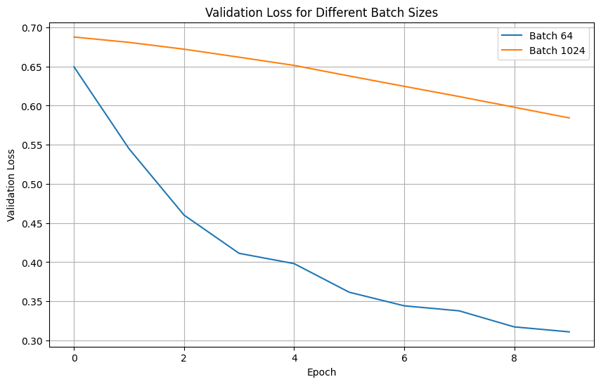

```python
plt.figure(figsize=(10,6))
for b in batch_sizes:
    plt.plot(batch_results[b]['val_loss'], label=f'Batch {b}')
plt.title('Validation Loss for Different Batch Sizes')
plt.xlabel('Epoch')
plt.ylabel('Validation Loss')
plt.grid(True)
plt.legend()
plt.show()
```

The analysis aimed to investigate two key aspects:

1. The impact of smaller versus larger batch sizes on model convergence.
2. The effectiveness of each batch size in enhancing the model's ability to generalize on unseen data.

Based on our findings, we recommend using smaller batch sizes when generalization is of utmost importance and when time or resource constraints permit a longer training duration.

Finally, using the size of dictionary you find to be sufficient and the original batch size of 512, test out a higher number of training epochs. Show a plot of the convergence of the model, and comment on the results.

```
40/40 ━━━━━━━━━━━━━━━━━━━━ 4s 66ms/step - accuracy: 0.5212 - loss: 0.6921 - val_accuracy: 0.5844 - val_loss: 0.6842
40/40 ━━━━━━━━━━━━━━━━━━━━ 5s 66ms/step - accuracy: 0.6161 - loss: 0.6812 - val_accuracy: 0.6676 - val_loss: 0.6717
40/40 ━━━━━━━━━━━━━━━━━━━━ 3s 74ms/step - accuracy: 0.6591 - loss: 0.6671 - val_accuracy: 0.5826 - val_loss: 0.6600
40/40 ━━━━━━━━━━━━━━━━━━━━ 5s 61ms/step - accuracy: 0.6567 - loss: 0.6536 - val_accuracy: 0.6578 - val_loss: 0.6378
40/40 ━━━━━━━━━━━━━━━━━━━━ 3s 61ms/step - accuracy: 0.7162 - loss: 0.6316 - val_accuracy: 0.6572 - val_loss: 0.6198
40/40 ━━━━━━━━━━━━━━━━━━━━ 3s 72ms/step - accuracy: 0.7252 - loss: 0.6116 - val_accuracy: 0.7556 - val_loss: 0.5925
40/40 ━━━━━━━━━━━━━━━━━━━━ 5s 58ms/step - accuracy: 0.7676 - loss: 0.5871 - val_accuracy: 0.7356 - val_loss: 0.5750
40/40 ━━━━━━━━━━━━━━━━━━━━ 2s 61ms/step - accuracy: 0.7550 - loss: 0.5695 - val_accuracy: 0.7862 - val_loss: 0.5504
40/40 ━━━━━━━━━━━━━━━━━━━━ 2s 61ms/step - accuracy: 0.7963 - loss: 0.5430 - val_accuracy: 0.7018 - val_loss: 0.5518
40/40 ━━━━━━━━━━━━━━━━━━━━ 3s 70ms/step - accuracy: 0.7603 - loss: 0.5307 - val_accuracy: 0.7702 - val_loss: 0.5189
40/40 ━━━━━━━━━━━━━━━━━━━━ 3s 69ms/step - accuracy: 0.7957 - loss: 0.5061 - val_accuracy: 0.8150 - val_loss: 0.4953
40/40 ━━━━━━━━━━━━━━━━━━━━ 2s 59ms/step - accuracy: 0.8080 - loss: 0.4903 - val_accuracy: 0.7856 - val_loss: 0.4883
40/40 ━━━━━━━━━━━━━━━━━━━━ 3s 66ms/step - accuracy: 0.8191 - loss: 0.4726 - val_accuracy: 0.8330 - val_loss: 0.4646
40/40 ━━━━━━━━━━━━━━━━━━━━ 6s 87ms/step - accuracy: 0.8417 - loss: 0.4518 - val_accuracy: 0.8348 - val_loss: 0.4519
40/40 ━━━━━━━━━━━━━━━━━━━━ 2s 58ms/step - accuracy: 0.8359 - loss: 0.4434 - val_accuracy: 0.8050 - val_loss: 0.4519
40/40 ━━━━━━━━━━━━━━━━━━━━ 2s 60ms/step - accuracy: 0.8324 - loss: 0.4316 - val_accuracy: 0.7974 - val_loss: 0.4469
40/40 ━━━━━━━━━━━━━━━━━━━━ 2s 60ms/step - accuracy: 0.8386 - loss: 0.4141 - val_accuracy: 0.8450 - val_loss: 0.4196
40/40 ━━━━━━━━━━━━━━━━━━━━ 3s 60ms/step - accuracy: 0.8604 - loss: 0.4036 - val_accuracy: 0.8468 - val_loss: 0.4115
40/40 ━━━━━━━━━━━━━━━━━━━━ 4s 98ms/step - accuracy: 0.8630 - loss: 0.3890 - val_accuracy: 0.8522 - val_loss: 0.4009
40/40 ━━━━━━━━━━━━━━━━━━━━ 2s 59ms/step - accuracy: 0.8707 - loss: 0.3779 - val_accuracy: 0.8120 - val_loss: 0.4136
```

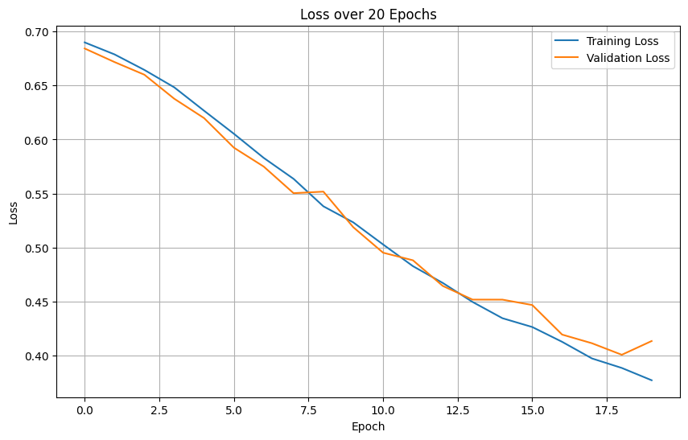

```python
hist_long, test_loss, test_acc = imdb_data(vocab_size=10000, batch_size=512, epochs=20)


plt.figure(figsize=(10,6))
plt.plot(hist_long.history['loss'], label='Training Loss')
plt.plot(hist_long.history['val_loss'], label='Validation Loss')
plt.title('Loss over 20 Epochs')
plt.xlabel('Epoch')
plt.ylabel('Loss')
plt.legend()
plt.grid(True)
plt.show()
```

## Exercise 2

Consider the RNN we fit to the NYSE data. Modify the code to allow inclusion of the variable day of week, and fit the RNN. Compute the test R2 .

```python
# Load the NYSE dataset from ISLP GitHub repo
NYSE = pd.read_csv('https://raw.githubusercontent.com/intro-stat-learning/ISLP/refs/heads/main/ISLP/data/NYSE.csv',
                   index_col=0, parse_dates=True)

# Choose the target variable (you can switch to 'DJ_return' or 'log_volatility')
target_col = 'log_volume'

# Define the numeric columns we will use for predictors
cols = ['DJ_return', 'log_volume', 'log_volatility']

# Standardize the numeric columns to zero mean and unit variance
scaler = StandardScaler()
X_scaled = pd.DataFrame(scaler.fit_transform(NYSE[cols]), columns=cols, index=NYSE.index)

# Add the target variable back to the scaled DataFrame
X_scaled['target'] = X_scaled[target_col]

# Extract the day of the week from the date index (0=Monday, 6=Sunday)
X_scaled['day_of_week'] = X_scaled.index.dayofweek

# Convert 'day_of_week' into dummy variables (one-hot encoding), drop the first to avoid collinearity
X_scaled = pd.get_dummies(X_scaled, columns=['day_of_week'], drop_first=True)
```

```python
# Function to create lagged features for time series modeling
def create_lags(data, lags=5):
    for i in range(1, lags + 1):
        # For each lag, shift all predictor columns by i days
        data[[f'{col}_lag{i}' for col in cols]] = data[cols].shift(i)
    return data.dropna()  # Remove rows with NaNs caused by shifting
```

```python
# Apply the lag function to create 5 lagged variables
X_lagged = create_lags(X_scaled)

# Remove target and get feature matrix (X)
X = X_lagged.drop(columns=['target']).astype('float32').values
# Set up the target array (y)
y = X_lagged['target'].values

# Reshape X into 3D format expected by RNN: (samples, timesteps, features)
X_rnn = X.reshape(X.shape[0], X.shape[1], 1)

# Split the dataset into training and test sets (80/20)
X_train, X_test, y_train, y_test = train_test_split(X_rnn, y, test_size=0.2, random_state=42)
```

```python
# Define a simple RNN model
model = Sequential([
    SimpleRNN(10, input_shape=(X_train.shape[1], 1)),  # RNN with 10 units
    Dense(1)  # Output layer for regression
])
```

```python
# Compile the model with mean squared error loss
model.compile(optimizer='adam', loss='mse')

# Train the model for 20 epochs
model.fit(X_train, y_train, epochs=20, verbose=1)

# Use the trained model to predict on the test set
y_pred = model.predict(X_test)

# Calculate and print the R^2 score on the test set
r2 = r2_score(y_test, y_pred)
print(f"Test R² Score with day_of_week and lags: {r2:.4f}")
```

```
152/152 ━━━━━━━━━━━━━━━━━━━━ 2s 5ms/step - loss: 1.2447
152/152 ━━━━━━━━━━━━━━━━━━━━ 1s 5ms/step - loss: 0.5084
152/152 ━━━━━━━━━━━━━━━━━━━━ 1s 5ms/step - loss: 0.3329
152/152 ━━━━━━━━━━━━━━━━━━━━ 1s 5ms/step - loss: 0.2674
152/152 ━━━━━━━━━━━━━━━━━━━━ 1s 5ms/step - loss: 0.1781
152/152 ━━━━━━━━━━━━━━━━━━━━ 1s 5ms/step - loss: 0.1317
152/152 ━━━━━━━━━━━━━━━━━━━━ 1s 5ms/step - loss: 0.1133
152/152 ━━━━━━━━━━━━━━━━━━━━ 1s 8ms/step - loss: 0.0970
152/152 ━━━━━━━━━━━━━━━━━━━━ 1s 7ms/step - loss: 0.0889
152/152 ━━━━━━━━━━━━━━━━━━━━ 1s 5ms/step - loss: 0.0819
152/152 ━━━━━━━━━━━━━━━━━━━━ 1s 5ms/step - loss: 0.0733
152/152 ━━━━━━━━━━━━━━━━━━━━ 1s 5ms/step - loss: 0.0613
152/152 ━━━━━━━━━━━━━━━━━━━━ 1s 5ms/step - loss: 0.0614
152/152 ━━━━━━━━━━━━━━━━━━━━ 1s 6ms/step - loss: 0.0518
152/152 ━━━━━━━━━━━━━━━━━━━━ 1s 6ms/step - loss: 0.0647
152/152 ━━━━━━━━━━━━━━━━━━━━ 1s 6ms/step - loss: 0.0452
152/152 ━━━━━━━━━━━━━━━━━━━━ 1s 5ms/step - loss: 0.0471
152/152 ━━━━━━━━━━━━━━━━━━━━ 1s 5ms/step - loss: 0.0484
152/152 ━━━━━━━━━━━━━━━━━━━━ 1s 5ms/step - loss: 0.0429
152/152 ━━━━━━━━━━━━━━━━━━━━ 1s 7ms/step - loss: 0.0416
38/38 ━━━━━━━━━━━━━━━━━━━━ 1s 9ms/step
Test R² Score with day_of_week and lags: 0.9604
```

Now, modify the code to have 7 lags instead of 5. What does this change about the network? How does it affect your results?

```python
# Apply the lag function to create 5 lagged variables
X_lagged = create_lags(X_scaled, lags = 7)

# Remove target and get feature matrix (X)
X = X_lagged.drop(columns=['target']).astype('float32').values
# Set up the target array (y)
y = X_lagged['target'].values

# Reshape X into 3D format expected by RNN: (samples, timesteps, features)
X_rnn = X.reshape(X.shape[0], X.shape[1], 1)

# Split the dataset into training and test sets (80/20)
X_train, X_test, y_train, y_test = train_test_split(X_rnn, y, test_size=0.2, random_state=42)
```

```python
# Define a simple RNN model
model = Sequential([
    SimpleRNN(10, input_shape=(X_train.shape[1], 1)),  # RNN with 10 units
    Dense(1)  # Output layer for regression
])
```

```python
# Compile the model with mean squared error loss
model.compile(optimizer='adam', loss='mse')

# Train the model for 20 epochs
model.fit(X_train, y_train, epochs=20, verbose=1)

# Use the trained model to predict on the test set
y_pred = model.predict(X_test)

# Calculate and print the R^2 score on the test set
r2 = r2_score(y_test, y_pred)
print(f"Test R² Score with day_of_week and lags: {r2:.4f}")
```

```
152/152 ━━━━━━━━━━━━━━━━━━━━ 3s 6ms/step - loss: 0.8934
152/152 ━━━━━━━━━━━━━━━━━━━━ 1s 6ms/step - loss: 0.5017
152/152 ━━━━━━━━━━━━━━━━━━━━ 1s 6ms/step - loss: 0.4254
152/152 ━━━━━━━━━━━━━━━━━━━━ 1s 6ms/step - loss: 0.3839
152/152 ━━━━━━━━━━━━━━━━━━━━ 1s 6ms/step - loss: 0.3288
152/152 ━━━━━━━━━━━━━━━━━━━━ 1s 6ms/step - loss: 0.3021
152/152 ━━━━━━━━━━━━━━━━━━━━ 1s 7ms/step - loss: 0.2696
152/152 ━━━━━━━━━━━━━━━━━━━━ 1s 9ms/step - loss: 0.3064
152/152 ━━━━━━━━━━━━━━━━━━━━ 1s 9ms/step - loss: 0.3076
152/152 ━━━━━━━━━━━━━━━━━━━━ 1s 6ms/step - loss: 0.2662
152/152 ━━━━━━━━━━━━━━━━━━━━ 1s 6ms/step - loss: 0.2346
152/152 ━━━━━━━━━━━━━━━━━━━━ 1s 6ms/step - loss: 0.2203
152/152 ━━━━━━━━━━━━━━━━━━━━ 1s 6ms/step - loss: 0.1898
152/152 ━━━━━━━━━━━━━━━━━━━━ 1s 6ms/step - loss: 0.1807
152/152 ━━━━━━━━━━━━━━━━━━━━ 1s 6ms/step - loss: 0.1901
152/152 ━━━━━━━━━━━━━━━━━━━━ 1s 6ms/step - loss: 0.1731
152/152 ━━━━━━━━━━━━━━━━━━━━ 1s 6ms/step - loss: 0.2283
152/152 ━━━━━━━━━━━━━━━━━━━━ 1s 6ms/step - loss: 0.1511
152/152 ━━━━━━━━━━━━━━━━━━━━ 1s 9ms/step - loss: 0.1311
152/152 ━━━━━━━━━━━━━━━━━━━━ 2s 10ms/step - loss: 0.1277
38/38 ━━━━━━━━━━━━━━━━━━━━ 0s 7ms/step
Test R² Score with day_of_week and lags: 0.8684
```

### RNN with 7 Lags

We extended the RNN model by using 7 lagged time steps instead of 5. This increased the model's input dimensionality and temporal context.

- Training loss decreased well, indicating learning.
- Validation (test) R² dropped from 0.9604 to 0.8684.
- This suggests that adding more lags made learning harder or introduced overfitting/instability.

Adding more lag steps provides more historical context, but too many lags may reduce generalization if they include noise or irrelevant patterns. The best lag length depends on the problem and should be tuned based on validation performance.